# Kas indeksifondid on riskantsemad kui tavalised?

Tõnu Pekk

5/26/2019

dude, tee nüüd githubi integratsioon ka kärmelt ära https://resources.github.com/whitepapers/github-and-rstudio/

Tõmbame indeksifondide viimase kahe aasta andmed pensionikeskusest.

```r
algkuup <- "02.05.2017"
loppkuup <- "20.05.2019"
fond1 = 73 #LHV Indeks
fond2 = 74 #Swed K99-00
fond3 = 75 #SEB Indeks
fond4 = 77 #Tuleva Maailma Aktsiad
```

Kui palju siis indeksifondide tootlused kõiguvad? Tavaline osakuhinna graafik näeb välja selline:

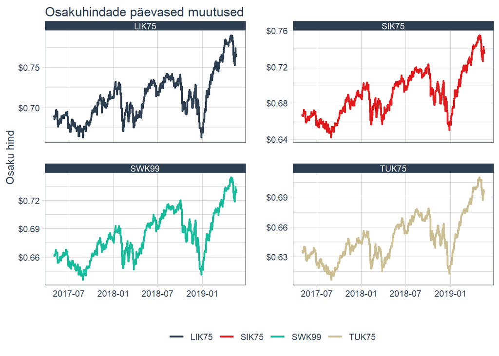

Ilma kogenud graafikulugeja-statistiku kogemuseta on siiski sellise joone pealt väga raske midagi välja lugeda fondi riskantsuse kohta. Vaatame korraks selle inimese pilguga, kes kord kuus oma pensionikontot vaatab.

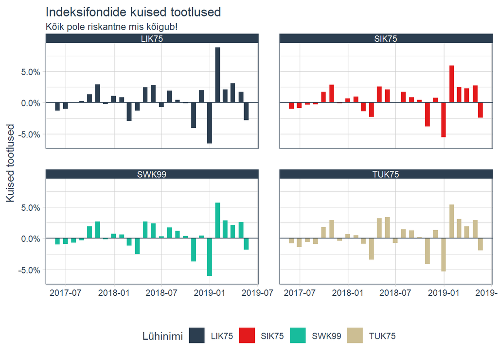

Lisaks graafikutele võib statistika-pakettide abil ka igasuguseid numbreid välja arvutada. Pensionikeskus arvutab näiteks standardhälvet:

```
## # A tibble: 4 x 2
## # Groups:   Lühinimi [4]
##   Lühinimi   sd.1
##   <fct>     <dbl>
## 1 SWK99    0.0243
## 2 LIK75    0.0293
## 3 SIK75    0.0241
## 4 TUK75    0.0253
```

Võib vaadata ka, kui palju maksimaalne langus on fondidel olnud (tipust põhja ehk drawdown)

```
## # A tibble: 4 x 2
## # Groups:   Lühinimi [4]
##   Lühinimi maxDrawdown.1
##   <fct>            <dbl>
## 1 SWK99           0.0915
## 2 LIK75           0.0869
## 3 SIK75           0.0844
## 4 TUK75           0.0800
```

Mõnikord soovitavad pankade müügimehed, et tasub oma riske hajutada ning jagada oma II samba vara mitme fondi vahel. Proovime, kas see aitab riski vähendada, kui jagame oma raha võrdselt 4 fondi vahel. Ei vähenda.

```r
wts <- c(0.25, 0.25, 0.25, 0.25)
portfelli.kuised.tootlused <- nav1.kuised.tootlused %>%
    tq_portfolio(assets_col  = Lühinimi,
                 returns_col = monthly.returns,
                 weights     = wts)

portfelli.kuised.tootlused %>%
  tq_performance(Ra = portfolio.returns,
                 performance_fun = sd)
```

```
## # A tibble: 1 x 1
##     sd.1
##    <dbl>
## 1 0.0254
```

```r
portfelli.kuised.tootlused %>%
  tq_performance(Ra = portfolio.returns,
                 performance_fun = maxDrawdown)
```

```
## # A tibble: 1 x 1
##   maxDrawdown.1
##           <dbl>
## 1        0.0855
```

Riski aitab vähendada ainult üks asi - tuleb osa portfellist panna riskivabadesse võlakirjadesse. Näiteks kui pool oma II samba varast Tuleva aktsiafondi indeksifondi ja pool Tuleva võlakirjafondi, on tulemus selline. Risk vähenes poole võrra.

```
## # A tibble: 1 x 1
##     sd.1
##    <dbl>
## 1 0.0130
```

```
## # A tibble: 1 x 1
##   maxDrawdown.1
##           <dbl>
## 1        0.0369
```

Mõni pensionifond väidab siiski, et nemad suudavad aktiivse juhtimisega riski vähendada nii, nagu investor seda ise ei suuda. Kuna eelpool nägime kuidas tootlusest loobudes saab igaüks riski lihtsalt vähendada, siis eeldan, et aktiivselt juhitavad pensionifondid püüavad riski vähendada nii, et tootlus ei lange. Vaatame nt Eesti suurima fondi Swedbank K3 riskitaset. Tundub, et üsna sarnane meie eelmises näites tehtud 50/50 portfellile:

```
## # A tibble: 1 x 1
##     sd.1
##    <dbl>
## 1 0.0125
```

```
## # A tibble: 1 x 1
##   maxDrawdown.1
##           <dbl>
## 1        0.0456
```

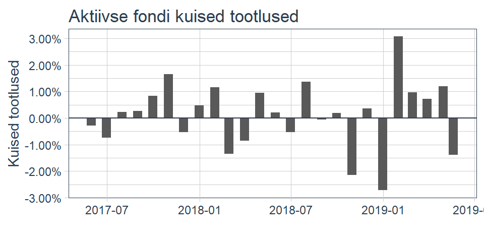

```r
nav3.kuised.tootlused %>%
    ggplot(aes(x = Kuupäev, y = monthly.returns)) +
    geom_bar(stat = "identity") +
    geom_hline(yintercept = 0, color = palette_light()[[1]]) +
    scale_y_continuous(labels = scales::percent) +
    labs(title = "Aktiivse fondi kuised tootlused",
         y = "Kuised tootlused", x = "") +
    #facet_wrap(~ Lühinimi, ncol = 2) +
    theme_tq() +
    scale_fill_tq()
```

Siia lõppu võiks veel ühele graafikule kõik kokku panna.